# R Notebook on EM algorithm

# The Faithful Data

The **faithful** data consist of the waiting time between eruptions and the duration of the eruption for the Old Faithful geyser in Yellowstone National Park, Wyoming, USA.

```r
data("faithful")
head(faithful)
```

|  | eruptions | waiting |
| --- | --- | --- |
| 1 | 3.600 | 79 |
| 2 | 1.800 | 54 |
| 3 | 3.333 | 74 |
| 4 | 2.283 | 62 |
| 5 | 4.533 | 85 |
| 6 | 2.883 | 55 |

We will consider the waiting time in the following. Let us display the empirical distribution of this variable.

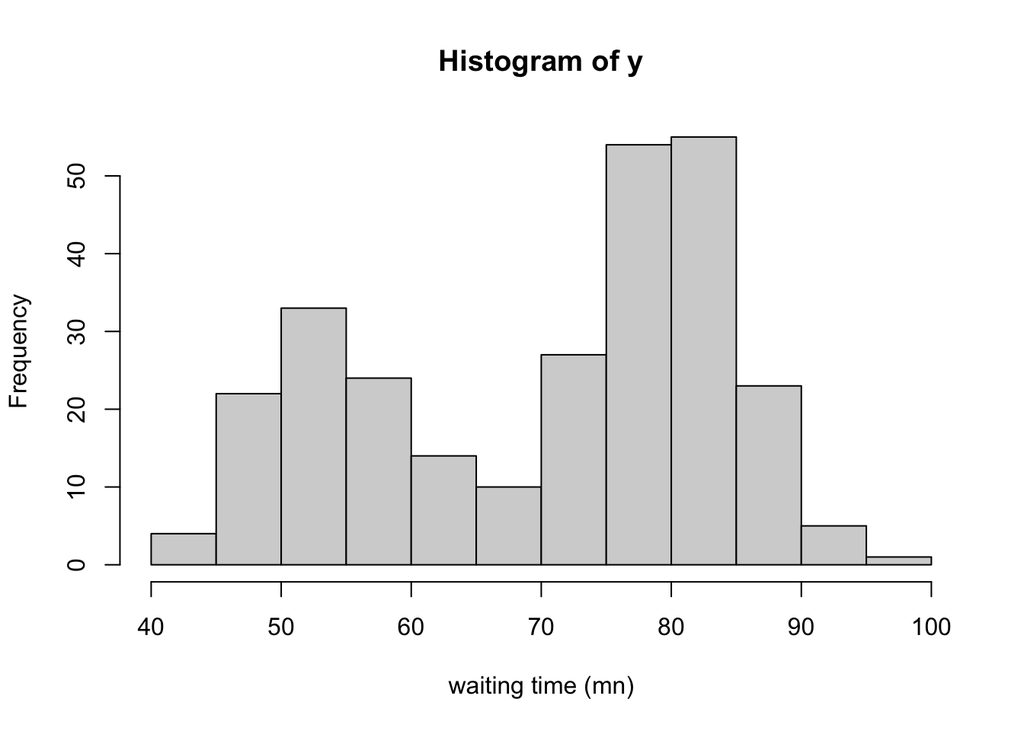

```r
y = faithful$waiting
hist(y, xlab="waiting time (mn)")
```

We clearly see 2 modes: the waiting times seem to be distributed either around 50mn or around 80mn.

# K-Means Clustering

Imagine that we want to partition the data $(y_i,1≤i≤n)$ into $L$ clusters. Let $\mu_1,\cdots,\mu_L$ be the $L$ centers of these $L$ clusters. A way to decide to which cluster belongs an observation $y_i$ consists in minimizing the distance between $y_i$ and the centers $(\mu_\ell)$.

Let $z_i$ be a label variable such that $z_i=\ell$ if observation $i$ belongs to cluster $\ell$. Then, the centers $(\mu_\ell)$ can be estimated by minimizing the within-cluster sum of squares
$$\begin{align*}U(\mu_1,\cdots,\mu_L)&=\sum_{i=1}^n \min_{\ell\in\{1,\cdots,L\}}(y_i-\mu_\ell)^2\\
&=\sum_{i=1}^2(y_i-\mu_{z_i})^2\\
&=\sum_{i=1}^n\sum_{l=1}^L(y_i-\mu_\ell)^2\mathbb{I}(z_i=\ell).
\end{align*}$$

For $\ell=1,2,…,L$, the solution $\hat{\mu}_\ell$ is the empirical mean computed in cluster $\ell$. Let $n_\ell=\sum_{i=1}^n\mathbb{I}(z_i=\ell)$ be the number of observation belonging to cluster $\ell$. Then
$$\hat{\mu}_\ell=\frac{1}{n_\ell}\sum_{i=1}^ny_i\mathbb{I}(z_i=\ell)$$
.

Let us compute the centers of the two cluster for our faithful data （k-means clustering）:

```r
U <- function(mu,y) {
  e1 <- (y-mu[1])^2
  e2 <- (y-mu[2])^2
  e.min <- pmin(e1,e2)
  e <- sum(e.min)
  return(e)
}

r.cluster <- nlm(U,c(50,80),y)
mu.est <- r.cluster$estimate
print(mu.est)
```

```
## [1] 54.74997 80.28484
```

We can then classify the n observations into these 2 clusters

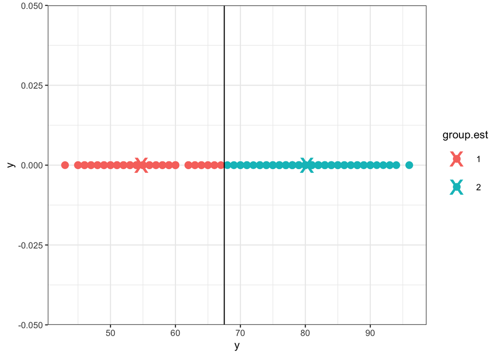

```r
e1 <- (y-mu.est[1])^2
e2 <- (y-mu.est[2])^2
group.est <- rep(1,length(y))
group.est[which(e2<e1)] <- 2
group.est <- as.factor(group.est)

library(ggplot2)
theme_set(theme_bw())

ggplot() + geom_point(data=data.frame(y,group.est), aes(x=y,y=0,colour=group.est),size=3) + geom_point(data=data.frame(y=mu.est,group=factor(c(1,2))), aes(y,0,colour=group),size=10, shape="x")+ geom_vline(xintercept=mean(mu.est))
```

and compute the sizes, the empirical means and standard deviations for each cluster:

```r
print(c(length(y[group.est==1]),length(y[group.est==2])))
```

```
## [1] 100 172
```

```r
print(c(mean(y[group.est==1]),mean(y[group.est==2])))
```

```
## [1] 54.75000 80.28488
```

```r
print(c(sd(y[group.est==1]),sd(y[group.est==2])))
```

```
## [1] 5.895341 5.627335
```

**Remark**: we could equivalently the function **kmeans**:

```r
r.km <- kmeans(y, centers=2)
r.km$cluster
```

```
##   [1] 2 1 2 1 2 1 2 2 1 2 1 2 2 1 2 1 1 2 1 2 1 1 2 2 2 2 1 2 2 2 2 2 1 2 2 1 1
##  [38] 2 1 2 2 1 2 1 2 2 1 1 2 1 2 2 1 2 1 2 2 1 2 2 1 2 1 2 1 2 2 2 1 2 2 1 2 2
##  [75] 1 2 1 2 2 2 2 2 2 1 2 2 2 2 1 2 1 2 1 2 1 2 2 2 1 2 1 2 1 2 2 1 2 1 2 2 2
## [112] 1 2 2 1 2 1 2 1 2 1 2 2 1 2 2 1 2 1 2 1 2 1 2 1 2 1 2 1 2 2 1 2 2 2 1 2 1
## [149] 2 1 2 2 1 2 2 2 2 2 1 2 1 2 1 2 1 2 1 2 1 2 1 1 2 2 2 2 2 1 2 2 1 2 2 2 1
## [186] 2 2 1 2 1 2 1 2 2 2 2 2 2 1 2 1 2 2 1 2 1 2 2 1 2 2 2 1 2 1 2 1 2 1 2 1 2
## [223] 1 2 2 2 2 2 2 2 2 1 2 1 2 1 1 2 2 1 2 1 2 1 2 2 1 2 1 2 1 2 2 2 2 2 2 2 1
## [260] 2 2 2 1 2 1 1 2 2 1 2 1 2
```

```r
r.km$size
```

```
## [1] 100 172
```

```r
as.vector(r.km$centers)
```

```
## [1] 54.75000 80.28488
```

```r
sqrt(r.km$withinss/(r.km$size-1))
```

```
## [1] 5.895341 5.627335
```

# Mixture of probability distributions

The labels $z_1,\cdots.z_n$ are a sequence of random variables that take their values in $\{1,2,\cdots,L\}$ and such that, for $\ell=1,2,\cdots,L$,
$$\mathbb{P}(z_i=\ell)=\pi_\ell,$$
where $\sum_{\ell=1}^L\pi_\ell=1$.

The observations in group $\ell$, i.e. such $z_i=\ell$, are independent and follow a same probability distribution $f_\ell$,
$$y_i|z_i=\ell \sim f_{\ell}.$$

The maximum likelihood (ML) estimate cannot be computed in a closed form but several methods can be used for maximizing this likelihood function.

# Newton-Type Algorithm

For instance, a Newton-type algorithm can be used for minimizing the deviance $-2\log L(\boldsymbol{\theta},\boldsymbol{y})$.

```r
# a Newton-type algorithm can be used for minimizing the likelihood for Gaussian Mixture Model
mixt.deviance <- function(theta,y) {
  pi1    <- theta[1]
  pi2    <- 1 - pi1
  mu1    <- theta[2]
  mu2    <- theta[3]
  sigma1 <- theta[4]
  sigma2 <- theta[5]
  pdf <- pi1*dnorm(y,mu1,sigma1) + pi2*dnorm(y,mu2,sigma2)
  deviance <- -2*sum(log(pdf))
 return(deviance)
  }

y = faithful$waiting

r.nlm <- nlm(mixt.deviance,c(.25,52,82,10,10),y)
theta.est <- c(r.nlm$estimate[1], 1-r.nlm$estimate[1], r.nlm$estimate[2:5])
print(matrix(theta.est,nrow=3,byrow = T))
```

```
##            [,1]       [,2]
## [1,]  0.3608861  0.6391139
## [2,] 54.6148563 80.0910688
## [3,]  5.8712181  5.8677343
```

```r
print(mixt.deviance(r.nlm$estimate,y))
```

```
## [1] 2068.003
```

We can then plot the empirical distribution of the data together with the probability density function of the mixture:

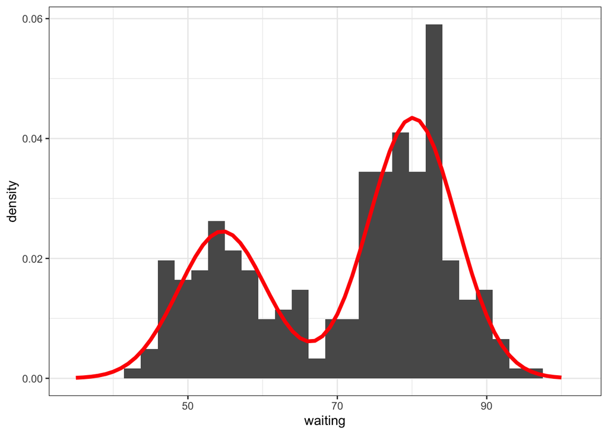

```r
dmixt <- function(x,theta) {
  pi1 <- theta[1]
  pi2 <- theta[2]
  mu1 <- theta[3]
  mu2 <- theta[4]
  sigma1 <- theta[5]
  sigma2 <- theta[6]
  f1 <- dnorm(x,mu1,sigma1)
  f2 <- dnorm(x,mu2,sigma2)
  f <- pi1*f1 + pi2*f2
}

x <- (35:100)
pdf.mixt <- dmixt(x,theta.est)
ggplot(data=faithful) + geom_histogram(aes(x=waiting, y=..density..), bins=30) +
  geom_line(data=data.frame(x,pdf.mixt), aes(x,pdf.mixt),colour="red",size=1.5)
```

Comparing the empirical and theoretical cumulative distribution functions (cdf) shows how well the mixture model fits the data

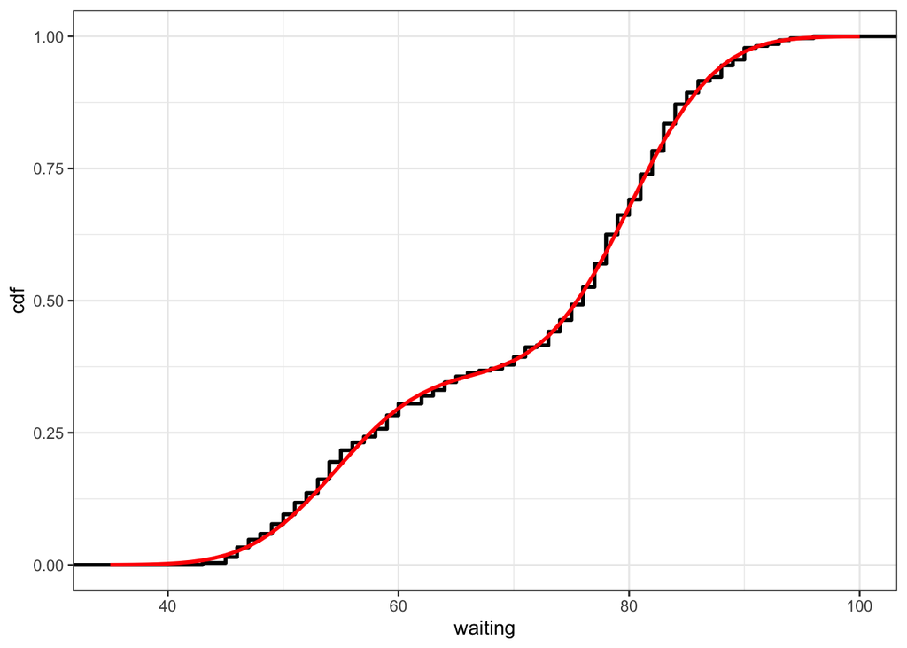

```r
pmixt <- function(x,theta) {
  pi1 <- theta[1]
  pi2 <- theta[2]
  mu1 <- theta[3]
  mu2 <- theta[4]
  sigma1 <- theta[5]
  sigma2 <- theta[6]
  F1 <- pnorm(x,mu1,sigma1)
  F2 <- pnorm(x,mu2,sigma2)
  F  <- pi1*F1 + pi2*F2
  return(F)
}
cdf.mixt <- pmixt(x,theta.est)

ggplot(data=faithful) + stat_ecdf(aes(waiting), geom = "step", size=1) +
  geom_line(data=data.frame(x,cdf.mixt), aes(x,cdf.mixt),colour="red",size=1) +
  ylab("cdf")
```

# EM Algorithm

EM algorithm:

Step 1 (Expectation step): Given the current guess of Gaussian components, we compute ownership of each point.

Step 2 (Maximization step): Given ownership probabilities, update Gaussian components to maximize likelihood function (calculate new means, variance and mixing weight).

Step3: Repeat step 1 and 2 until convergence.

The Expectation - Maximization (EM) algorithm implemented in the **mixtools** library could also be used for computing the ML estimate

```r
library(mixtools)
r.mixEM = normalmixEM(y)
```

```
## number of iterations= 42
```

```r
list(p=r.mixEM$lambda,mu=r.mixEM$mu,sigma=r.mixEM$sigma)
```

```
## $p
## [1] 0.3608869 0.6391131
##
## $mu
## [1] 54.61489 80.09109
##
## $sigma
## [1] 5.871243 5.867717
```

```r
-2*r.mixEM$loglik
```

```
## [1] 2068.003
```

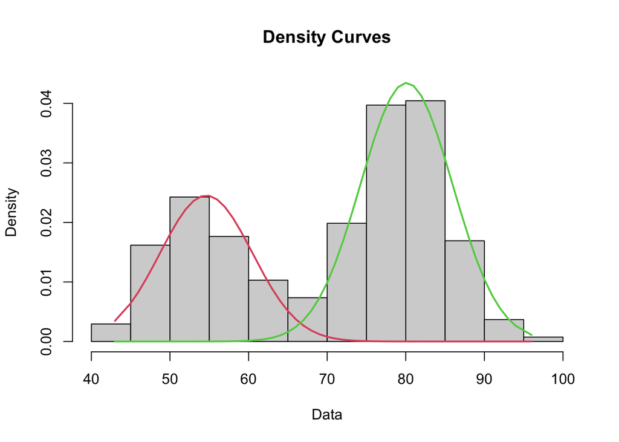

```r
plot(r.mixEM,which=2)
```

```r
head(r.mixEM$posterior)
```

```
##            comp.1       comp.2
## [1,] 1.030870e-04 9.998969e-01
## [2,] 9.999093e-01 9.066065e-05
## [3,] 4.135710e-03 9.958643e-01
## [4,] 9.673818e-01 3.261819e-02
## [5,] 1.223562e-06 9.999988e-01
## [6,] 9.998100e-01 1.899893e-04
```

# Mixture model versus clustering

Let us sample some data from a Gaussian mixture model.

```r
set.seed(12345)
y1 <- rnorm(120, 0, 1)
y2 <- rnorm(80, 3, 1)
y=c(y1, y2)
z=c(rep(1,120),rep(2,80))
d <- data.frame(y,z)
```

We can use the k-means method to create two clusters and compute the proportion, center and standard deviation for each cluster.

```r
r.km <- kmeans(y, centers=c(-1,1))
list(p=r.km$size/sum(r.km$size), mu=as.vector(r.km$centers), sigma=sqrt(r.km$withinss/r.km$size))
```

```
## $p
## [1] 0.53 0.47
##
## $mu
## [1] -0.04233643  2.90990098
##
## $sigma
## [1] 0.8947708 0.9812917
```

We can instead consider a Gaussian mixture model, use the EM algorithm with the same data and display the estimated parameters

```r
r.mixEM = normalmixEM(y)
```

```
## number of iterations= 303
```

```r
list(p=r.mixEM$lambda,mu=r.mixEM$mu,sigma=r.mixEM$sigma)
```

```
## $p
## [1] 0.5622311 0.4377689
##
## $mu
## [1] 0.1440742 2.8878443
##
## $sigma
## [1] 1.079719 1.110258
```

Since the ``true’’ labels are known, we can compute the classification error rate for each method (in % here):

```r
d$km <- r.km$cluster
d$EM <- (r.mixEM$posterior[,1]<0.5)+1
print(c(mean(d$z != d$km)*100, mean(d$z != d$EM)*100))
```

```
## [1] 12.0 10.5
```

The Gaussian mixture model is a model. It is an assumption or approximation to how the data (and future data, often) were generated.

K-means is an algorithm. Given a data set, it divides it into $k$ clusters in a way that attempts to minimize the average Euclidean distance from a point to the center of its clusters. We can use k-means clustering without any assumption about the data-generating process.